# Assignment 1 - Language development in autistic and neurotypical children

# Part 2 - Strong in the Bayesian ken, you are now ready to analyse the actual data

- Describe your sample (n, age, gender, clinical and cognitive features of the two groups) and critically assess whether the groups (ASD and TD) are balanced. Briefly discuss whether the data is enough given the simulations in part 1.
- Describe linguistic development (in terms of MLU over time) in TD and ASD children (as a function of group). Discuss the difference (if any) between the two groups.
- Describe individual differences in linguistic development: do all kids follow the same path? Are all kids reflected by the general trend for their group?
- Include additional predictors in your model of language development (N.B. not other indexes of child language: types and tokens, that’d be cheating). Identify the best model, by conceptual reasoning, model comparison or a mix. Report the model you choose (and name its competitors, if any) and discuss why it’s the best model.

```r
real_data <- read_csv('assignment_data_clean.csv')
unique(real_data$id)
```

```
##  [1]  1 10 11 12 13 14 15 16 17 18 19  2 20 21 22 23 24 25 26 27 28 29  3 30 31
## [26] 32 33 34 35 36 37 38 39  4 40 41 42 43 44 45 46 47 48 49  5 50 51 52 53 54
## [51] 55 56 57 58 59  6 60 61  7  8  9
```

```r
real_data <- real_data %>%
  mutate(Diagnosis=as.factor(Diagnosis))

real_data %>%
  group_by(Gender) %>%
  filter(visit==1) %>%
  count()
```

| Gender | n |
| --- | --- |
| female | 51 |
| male | 10 |

```r
#Counting participants
real_data %>%
  group_by(Diagnosis) %>%
  filter(visit==1) %>%
  count()
```

| Diagnosis | n |
| --- | --- |
| A | 29 |
| B | 32 |

```r
##o use lognormal distribution we cannot have negative MLU, so we filter it
real_data <- real_data %>%
  filter(!CHI_MLU<=0)
```

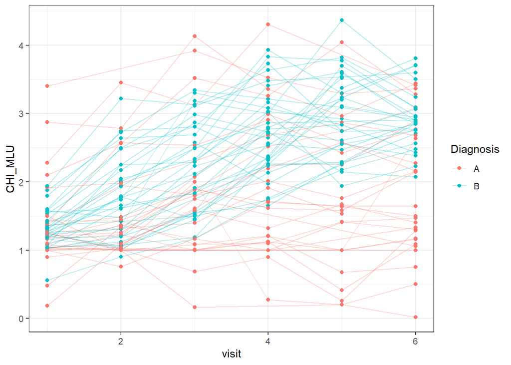

```r
ggplot(real_data, aes(visit,CHI_MLU, color=Diagnosis, group=id))+
  theme_bw()+
  geom_point()+
  geom_line(alpha=0.3)
```

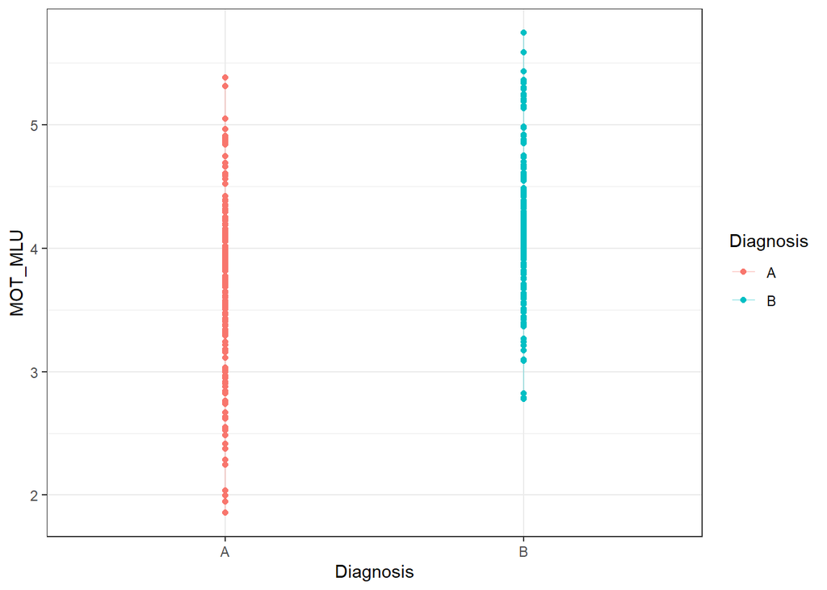

```r
ggplot(real_data, aes(Diagnosis, MOT_MLU, color=Diagnosis))+
  theme_bw()+
  geom_point()+
  geom_line(alpha=0.3)
```

```r
MLU_fit<- bf(CHI_MLU ~ 0 + Diagnosis + Diagnosis:visit + (1 + visit|id))

get_prior(data = real_data, family = lognorm_fam, MLU_fit)
```

| prior | class | coef | group | resp | dpar | nlpar | lb | ub | source |
| --- | --- | --- | --- | --- | --- | --- | --- | --- | --- |
|  | b |  |  |  |  |  |  |  | default |
|  | b | DiagnosisA |  |  |  |  |  |  | default |
|  | b | DiagnosisA:visit |  |  |  |  |  |  | default |
|  | b | DiagnosisB |  |  |  |  |  |  | default |
|  | b | DiagnosisB:visit |  |  |  |  |  |  | default |
| lkj(1) | cor |  |  |  |  |  |  |  | default |
|  | cor |  | id |  |  |  |  |  | default |
| student_t(3, 0, 2.5) | sd |  |  |  |  |  | 0 |  | default |
|  | sd |  | id |  |  |  |  |  | default |
|  | sd | Intercept | id |  |  |  |  |  | default |

[output cut: 2 more lines]

```r
#Simulating priors
priors_sim<-c(
prior(normal(0,0.2),class=b),
prior(normal(0.5,0.05),class=b,coef="DiagnosisA"),
prior(normal(0.5,0.02),class=b,coef="DiagnosisB"),
prior(normal(0,0.06),class=b,coef="DiagnosisA:visit"),
prior(normal(0,0.03),class=b,coef="DiagnosisB:visit"),
prior(normal(0,0.2),class=sd,coef=Intercept,group=id),
prior(normal(0,0.1),class=sd,coef=visit,group=id),
prior(normal(0,0.2),class=sigma),
prior(lkj(2),class="cor"))
```

```r
MLU_prior <- brm(
  MLU_fit,
  data = real_data,
  prior = priors_sim,
  family = lognorm_fam,
  refresh=0,
  sample_prior = 'only',
  iter=6000,
  warmup = 2500,
  backend = "cmdstanr",
  threads = threading(2),
  chains = 2,
  cores = 2,
  control = list(
    adapt_delta = 0.99,
    max_treedepth = 20
)
)
```

###prior predictive checks

[figure not shown]

```r
pp_check(MLU_prior, ndraws = 100)+
  xlim(-10,50)+
  ylim(0,500)
```

###fit the model

```r
MLU_prior_fit <- brm(
  MLU_fit,
  data = real_data,
  prior = priors_sim,
  family = lognorm_fam,
  refresh=0,
  sample_prior = TRUE,
  iter=6000,
  warmup = 2500,
  backend = "cmdstanr",
  threads = threading(2),
  chains = 2,
  cores = 2,
  control = list(
    adapt_delta = 0.99,
    max_treedepth = 20
)
)
```

Sara ###posterior predictive check

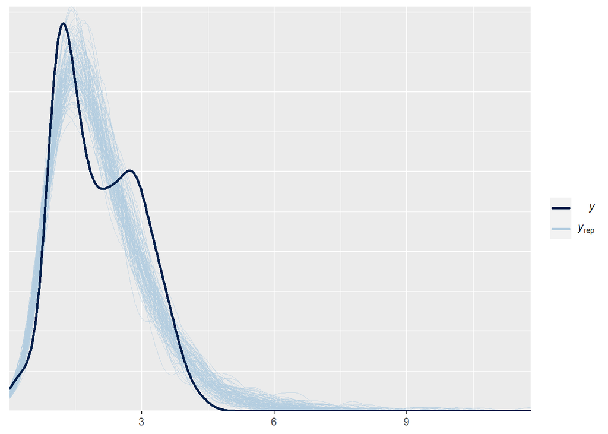

```r
pp_check(MLU_prior_fit, ndraws = 100)
```

###traceplot for fitted model

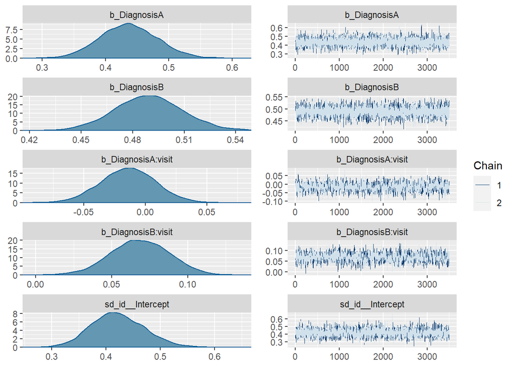

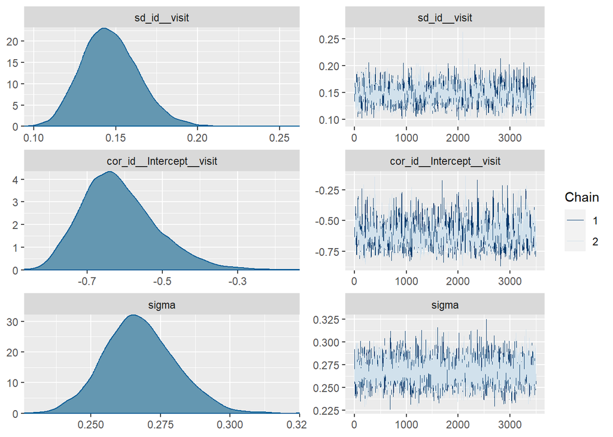

```r
plot(MLU_prior_fit, ndraws = 100)
```

### parameter recovery from fitted model

```r
print(MLU_prior_fit)
```

```
##  Family: lognormal
##   Links: mu = identity; sigma = identity
## Formula: CHI_MLU ~ 0 + Diagnosis + Diagnosis:visit + (1 + visit | id)
##    Data: real_data (Number of observations: 349)
##   Draws: 2 chains, each with iter = 6000; warmup = 2500; thin = 1;
##          total post-warmup draws = 7000
##
## Group-Level Effects:
## ~id (Number of levels: 61)
##                      Estimate Est.Error l-95% CI u-95% CI Rhat Bulk_ESS
## sd(Intercept)            0.42      0.05     0.33     0.52 1.00     2532
## sd(visit)                0.15      0.02     0.12     0.18 1.00      891
## cor(Intercept,visit)    -0.61      0.10    -0.78    -0.39 1.00      770
##                      Tail_ESS
## sd(Intercept)            4522
## sd(visit)                2270
## cor(Intercept,visit)     1836
##
## Population-Level Effects:
##                  Estimate Est.Error l-95% CI u-95% CI Rhat Bulk_ESS Tail_ESS
## DiagnosisA           0.44      0.04     0.35     0.53 1.00     6348     5528
## DiagnosisB           0.49      0.02     0.45     0.53 1.00    10730     5376
## DiagnosisA:visit    -0.01      0.02    -0.06     0.03 1.00     1301     2684
## DiagnosisB:visit     0.07      0.02     0.03     0.11 1.00     1158     2346
##
## Family Specific Parameters:
##       Estimate Est.Error l-95% CI u-95% CI Rhat Bulk_ESS Tail_ESS
## sigma     0.27      0.01     0.24     0.29 1.00     4392     4575
##
## Draws were sampled using sample(hmc). For each parameter, Bulk_ESS
## and Tail_ESS are effective sample size measures, and Rhat is the potential
## scale reduction factor on split chains (at convergence, Rhat = 1).
```

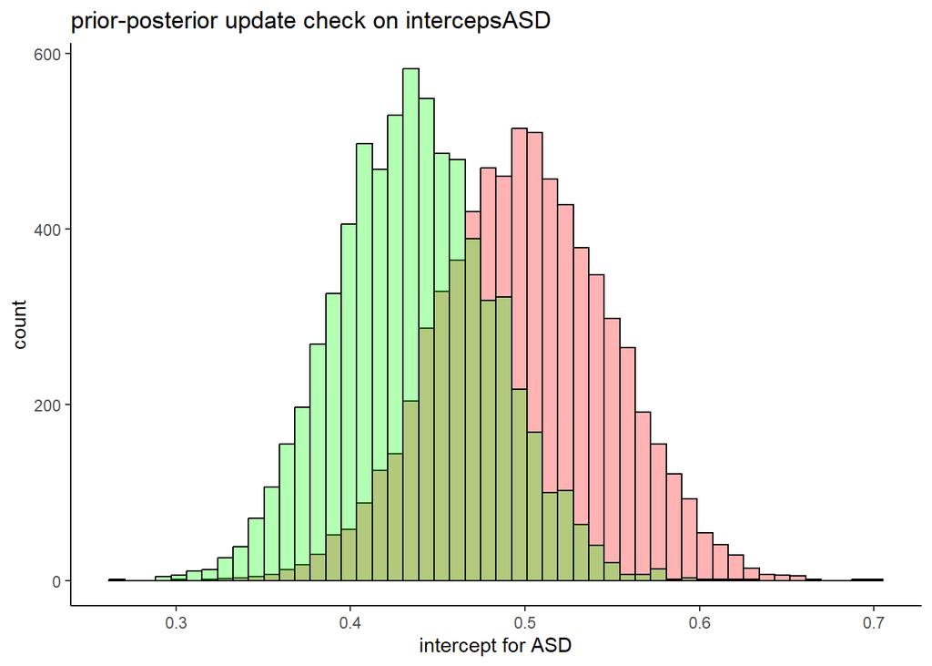

```r
posterior <- as_draws_df(MLU_prior_fit)

plot1 <- ggplot(posterior)+
  geom_histogram(aes(prior_b_DiagnosisA), fill='red', color='black', alpha=0.3, bins=50)+
  geom_histogram(aes(b_DiagnosisA), fill='green', color='black', alpha=0.3, bins=50)+
  theme_classic()+
  ggtitle('prior-posterior update check on intercepsASD')+
  xlab('intercept for ASD')

plot2 <- ggplot(posterior)+
  geom_histogram(aes(prior_b_DiagnosisB), fill='red', color='black', alpha=0.3, bins=50)+
  geom_histogram(aes(b_DiagnosisB), fill='green', color='black', alpha=0.3, bins=50)+
  theme_classic()+
  ggtitle('prior-posterior update check on intercept for TD')+
  xlab('intercept for TD')

plot3 <- ggplot(posterior)+
  geom_histogram(aes(`prior_b_DiagnosisA:visit`), fill='red', color='black', alpha=0.3, bins=50)+
  geom_histogram(aes(`b_DiagnosisA:visit`), fill='green', color='black', alpha=0.3, bins=50)+
  theme_classic()+
  ggtitle('prior-posterior update check on slope for ASD')+
  xlab("Slope for ASD")

plot4 <- ggplot(posterior)+
  geom_histogram(aes(`prior_b_DiagnosisB:visit`), fill='red', color='black', alpha=0.3, bins=50)+
  geom_histogram(aes(`b_DiagnosisB:visit`), fill='green', color='black', alpha=0.3, bins=50)+
  theme_classic()+
  ggtitle('prior-posterior update check on slope for TD')+
  xlab("slope for TD")


plot5 <- ggplot(posterior)+
  geom_histogram(aes(prior_cor_id), fill='red', color='black', alpha=0.3, bins=50)+
  geom_histogram(aes(cor_id__Intercept__visit), fill='green', color='black', alpha=0.3, bins=50)+
  theme_classic()+
  ggtitle('prior-posterior update check on correlation between varying intercepts and slopes')+
  xlab("Correlation")

plot6 <- ggplot(posterior)+
  geom_histogram(aes(prior_sd_id__Intercept), fill='red', color='black', alpha=0.3, bins=50)+
  geom_histogram(aes(sd_id__Intercept), fill='green', color='black', alpha=0.3, bins=50)+
  theme_classic()+
  ggtitle('Prior-posterior update check, the variability of the intercept')+
  xlab("Intercept")

plot7 <- ggplot(posterior)+
  geom_histogram(aes(prior_sd_id__visit), fill='red', color='black', alpha=0.3, bins=50)+
  geom_histogram(aes(sd_id__visit), fill='green', color='black', alpha=0.3, bins=50)+
  theme_classic()+
  ggtitle('Prior-posterior update check, the variability of the slopes')+
  xlab("Intercept")

plot8 <- ggplot(posterior)+
  geom_histogram(aes(`prior_b_DiagnosisA:visit`), fill='red', color='black', alpha=0.3, bins=50)+
  geom_histogram(aes(`b_DiagnosisA:visit`), fill='green', color='black', alpha=0.3, bins=50)+
  theme_classic()+
  geom_histogram(aes(`b_DiagnosisB:visit`), fill='yellow', color='black', alpha=0.3, bins=50)+
  theme_classic()+
  ggtitle('prior-posterior update check on slope')+
  xlab("Slope")

plot9 <- ggplot(posterior)+
  geom_histogram(aes(prior_b_DiagnosisA), fill='red', color='black', alpha=0.3, bins=50)+
  geom_histogram(aes(b_DiagnosisA), fill='green', color='black', alpha=0.3, bins=50)+
  theme_classic()+
   geom_histogram(aes(b_DiagnosisB), fill='yellow', color='black', alpha=0.3, bins=50)+
  theme_classic()+
  ggtitle('prior-posterior update check on interceps')+
  xlab('intercept')


plot1
```

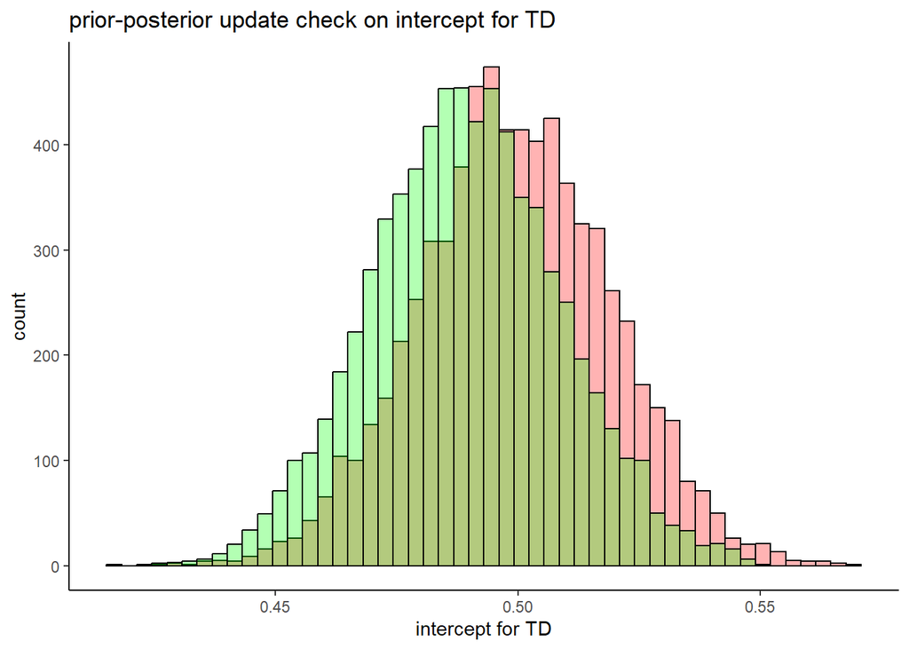

```r
plot2
```

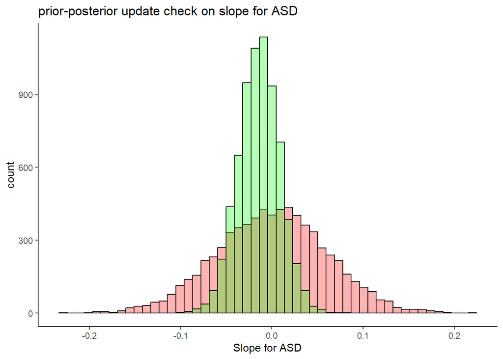

```r
plot3
```

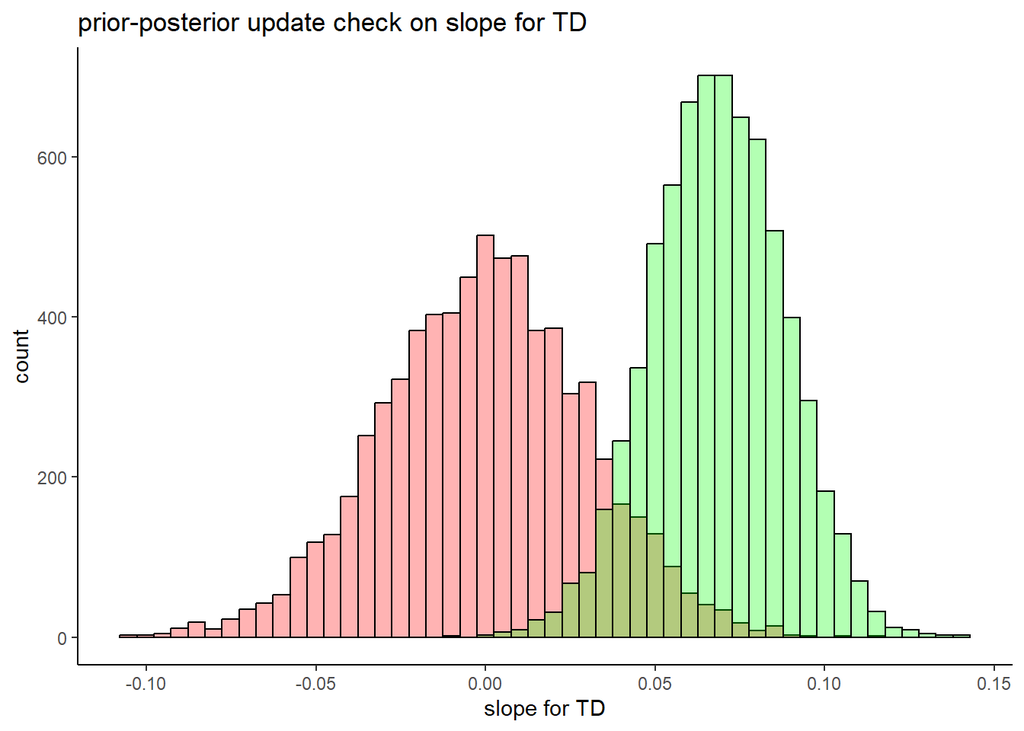

```r
plot4
```

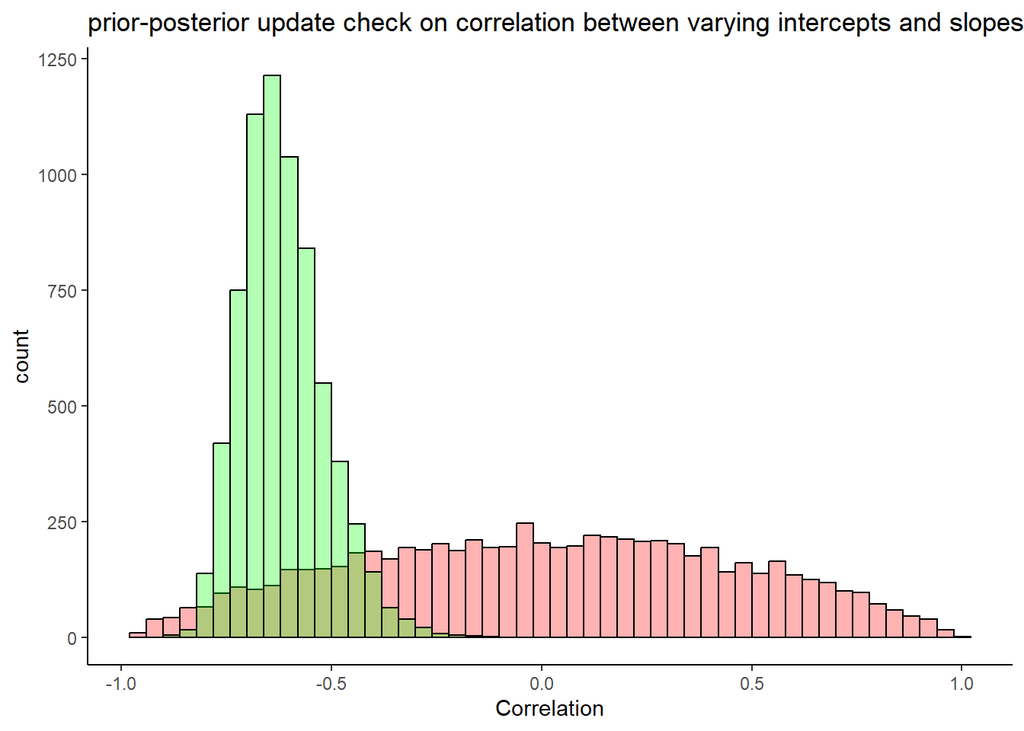

```r
plot5
```

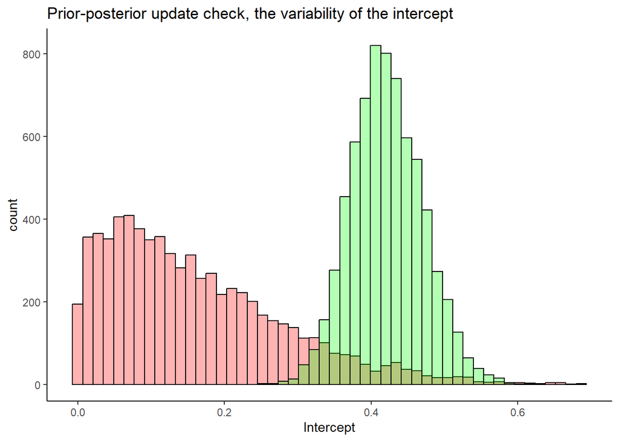

```r
plot6
```

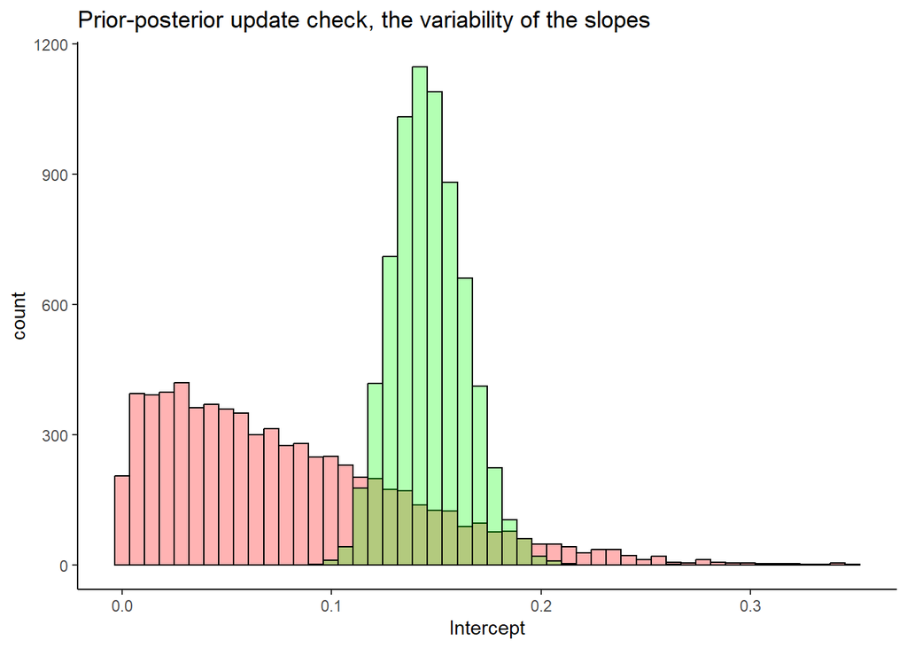

```r
plot7
```

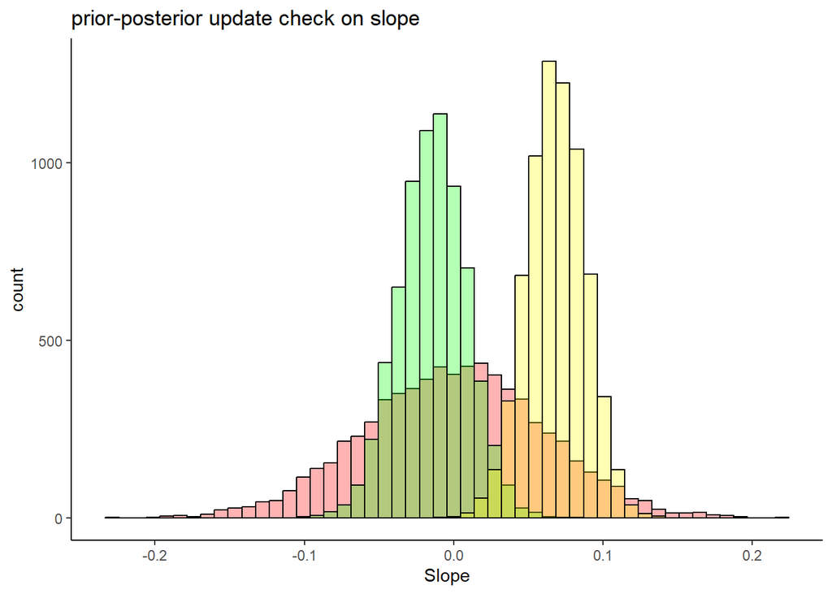

```r
plot8
```

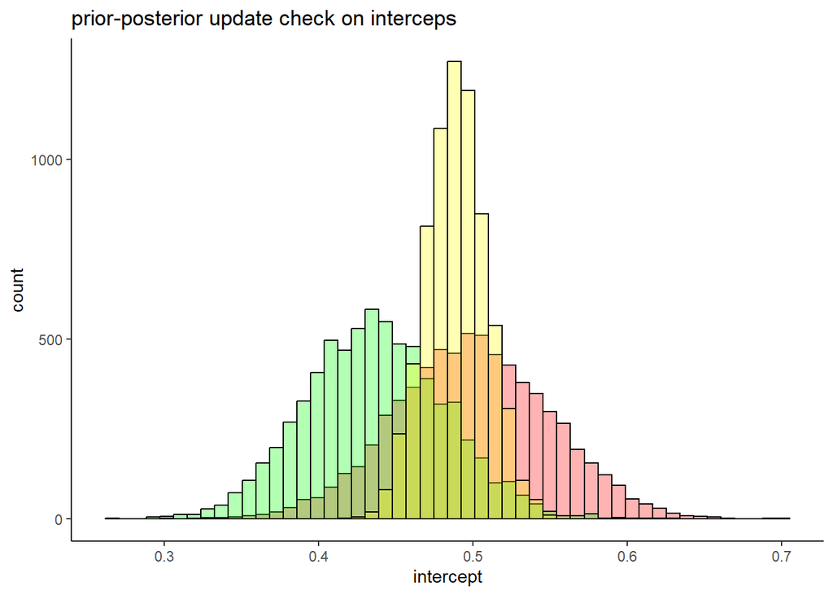

```r
plot9
```

```r
temp_re <- ranef(MLU_prior_fit)$id
for (i in unique(real_data$id)) {
  temp <- as.character(i)
  real_data$EstimatedIntercept[real_data$id == i] <- temp_re[,,'Intercept'][temp,1]
  real_data$EstimatedIntercept_low[real_data$id == i] <- temp_re[,,'Intercept'][temp,3]
  real_data$EstimatedIntercept_high[real_data$id == i] <- temp_re[,,'Intercept'][temp,4]
  real_data$EstimatedSlope[real_data$id == i] <- temp_re[,,'visit'][temp,1]
  real_data$EstimatedSlope_low[real_data$id == i] <- temp_re[,,'visit'][temp,3]
  real_data$EstimatedSlope_high[real_data$id == i] <- temp_re[,,'visit'][temp,4]
}
```

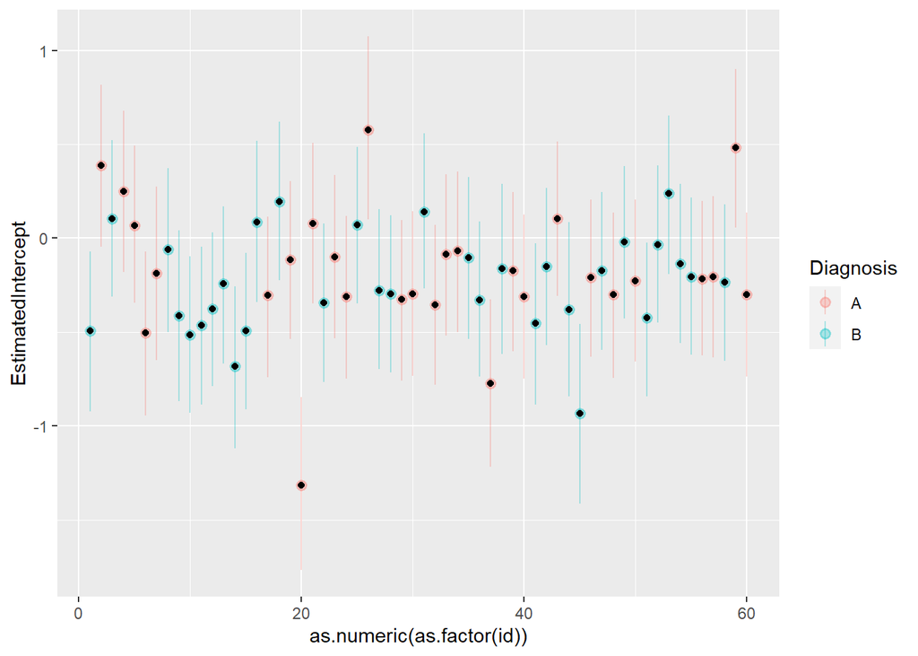

```r
d <- real_data %>% subset(visit == 1) %>%
  mutate(
    EstimatedIntercept = ifelse(Diagnosis == 'A',
                                    EstimatedIntercept + 0.44,
                                    EstimatedIntercept + 0.49),
    EstimatedIntercept_low = ifelse(Diagnosis == 'A',
                                   EstimatedIntercept_low + 0.44,
                                   EstimatedIntercept_low + 0.49),
    EstimatedIntercept_high = ifelse(Diagnosis == 'A',
                                     EstimatedIntercept_high + 0.44,
                                     EstimatedIntercept_high + 0.49)
)


d <- real_data %>% subset(visit == 1) %>%
  mutate(
    EstimatedSlope = ifelse(Diagnosis == 'A',
                                    EstimatedSlope - 0.01,
                                    EstimatedSlope + 0.07),
    EstimatedSlope_low = ifelse(Diagnosis == 'A',
                                   EstimatedSlope_low - 0.01,
                                   EstimatedSlope_low + 0.07),
    EstimatedSlope_high = ifelse(Diagnosis == 'A',
                                     EstimatedSlope_high - 0.01,
                                     EstimatedSlope_high + 0.07)
)

estimates_intercept <- ggplot(d) +
  geom_pointrange(aes( x = as.numeric(as.factor(id)), y = EstimatedIntercept,
                       ymin = EstimatedIntercept_low, ymax = EstimatedIntercept_high,
                       color = Diagnosis), alpha = 0.3) +
  geom_point(aes( x = as.numeric(as.factor(id)), y = EstimatedIntercept))

estimates_slopes <- ggplot(d) +
  geom_pointrange(aes( x = as.numeric(as.factor(id)), y = EstimatedSlope,
                       ymin = EstimatedSlope_low, ymax = EstimatedSlope_high,
                       color = Diagnosis), alpha = 0.3) +
  geom_point(aes( x = as.numeric(as.factor(id)), y = EstimatedSlope))

estimates_intercept
```

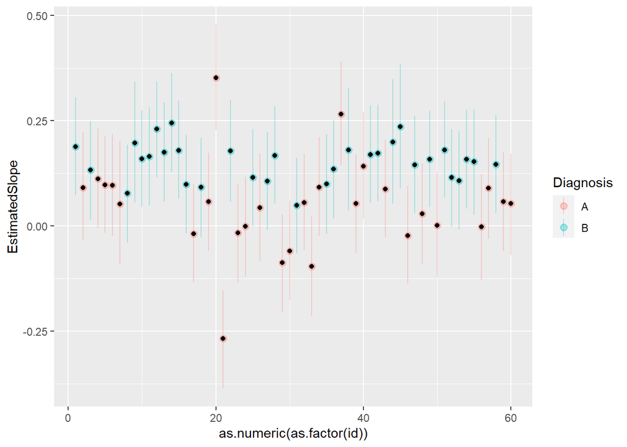

```r
estimates_slopes
```